# Lesson 2 - R Basics

### 01 - The Power of R

- Advantage of using R to perform Data Analysis
- Basic data types and commands of R

### Resources

- [Foodbourne Chicago finds Dodgy Restaurants with Tweets](http://blog.revolutionanalytics.com/2013/08/foodborne-chicago.html)
- [Sensitivity and Specificity and ROC Curves for Binary Classifiers](http://blog.yhathq.com/posts/roc-curves.html) (more advanced reading; focus on understanding TPR and FPR).

### 02 - The Power of R

- Used `textcat` package for analyzing tweets

### 03 - Why R

- We can build our analysis line by line
- Having R scripts allows you to easily share your work with others
- Has over 2000 user contributed packages
- Has large, active and growing community of users

Let’s see any example of what we can get out of R using a few lines of code

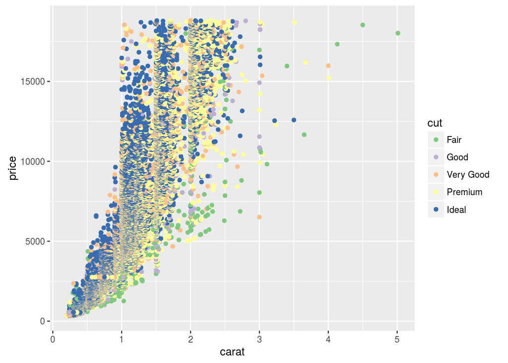

```r
#install.packages('ggplot2', dependencies = TRUE)
library(ggplot2)

#install.packages('RColorBrewer', dependencies = TRUE)
library(RColorBrewer)

data("diamonds")

qplot(data = diamonds, x = carat, y = price, color = cut) +
  scale_color_brewer(palette = 'Accent')
```

### 08 - Demystifying R

Go through `demystifying.R` to try out R.

### 10 - Getting Help

- Using `?FUNCTION` to get help for any function

#### Resources

- Quick R
- R Cookbook
- R-Bloggers
- StackOverflow About R
- StackOverflow R FAQ
- Google’s R Style Guide

### 11 - Read and Subset Data

```r
getwd()
```

```
## [1] "/home/aseem/projects/anshbansal.github.io/udacity_data_science_notes/Data_Analysis_with_R/lesson_02"
```

```r
#setwd('')
```

```r
statesInfo <- read.csv('./stateData.csv')
```

- Double clicking the data frame in Environment tab allows you to view the data in a tabular format in RStudio

```r
stateSubset <- subset(statesInfo, state.region == 1)
head(stateSubset, 2)
```

```
##              X state.abb state.area state.region population income
## 7  Connecticut        CT       5009            1       3100   5348
## 19       Maine        ME      33215            1       1058   3694
##    illiteracy life.exp murder highSchoolGrad frost  area
## 7         1.1    72.48    3.1           56.0   139  4862
## 19        0.7    70.39    2.7           54.7   161 30920
```

```r
dim(stateSubset)
```

```
## [1]  9 12
```

```r
stateSubsetBracket <- statesInfo[statesInfo$state.region == 1, ]
head(stateSubsetBracket, 2)
```

```
##              X state.abb state.area state.region population income
## 7  Connecticut        CT       5009            1       3100   5348
## 19       Maine        ME      33215            1       1058   3694
##    illiteracy life.exp murder highSchoolGrad frost  area
## 7         1.1    72.48    3.1           56.0   139  4862
## 19        0.7    70.39    2.7           54.7   161 30920
```

```r
dim(stateSubsetBracket)
```

```
## [1]  9 12
```

#### Resources

- Read this [fantastic tutorial](http://flowingdata.com/2015/02/18/loading-data-and-basic-formatting-in-r/) on loading data into R by Nathan Yau.
- [How to Subset Data](http://www.statmethods.net/management/subset.html)

### 12 - R Markdown Documents

- Go through `What_is_a_RMD_file.Rmd` file to see how a RMD file looks like
- The second file, `demystifyingR2.Rmd`, is the file that Chris mentions at the end of the video. Work through this file and use it to answer the next quiz!

You’ll need to install and load the package knitr in order to use the KNIT HTML button . Run the following commands in the RStudio console to install and load knitr.

```r
#install.packages('knitr', dependencies = T)
library(knitr)
```

### 13 - R Markdown Documents

Which cars have `mpg` greater than or equal to 30 or `hp` less than 60?

```r
data("mtcars")
str(mtcars)
```

```
## 'data.frame':    32 obs. of  11 variables:
##  $ mpg : num  21 21 22.8 21.4 18.7 18.1 14.3 24.4 22.8 19.2 ...
##  $ cyl : num  6 6 4 6 8 6 8 4 4 6 ...
##  $ disp: num  160 160 108 258 360 ...
##  $ hp  : num  110 110 93 110 175 105 245 62 95 123 ...
##  $ drat: num  3.9 3.9 3.85 3.08 3.15 2.76 3.21 3.69 3.92 3.92 ...
##  $ wt  : num  2.62 2.88 2.32 3.21 3.44 ...
##  $ qsec: num  16.5 17 18.6 19.4 17 ...
##  $ vs  : num  0 0 1 1 0 1 0 1 1 1 ...
##  $ am  : num  1 1 1 0 0 0 0 0 0 0 ...
##  $ gear: num  4 4 4 3 3 3 3 4 4 4 ...
##  $ carb: num  4 4 1 1 2 1 4 2 2 4 ...
```

```r
subset(mtcars, mpg >= 30 | hp < 60)
```

```
##                 mpg cyl disp  hp drat    wt  qsec vs am gear carb
## Fiat 128       32.4   4 78.7  66 4.08 2.200 19.47  1  1    4    1
## Honda Civic    30.4   4 75.7  52 4.93 1.615 18.52  1  1    4    2
## Toyota Corolla 33.9   4 71.1  65 4.22 1.835 19.90  1  1    4    1
## Lotus Europa   30.4   4 95.1 113 3.77 1.513 16.90  1  1    5    2
```

### 14 - Factor Variables

We will look at some data collected from survey of reddit users. This survey asked users about + Demographics - gender, nationality, employment + what type of cheese they would be + prefer dogs, cats or turtles

```r
reddit <- read.csv("reddit.csv")
str(reddit)
```

```
## 'data.frame':    32754 obs. of  14 variables:
##  $ id               : int  1 2 3 4 5 6 7 8 9 10 ...
##  $ gender           : int  0 0 1 0 1 0 0 0 0 0 ...
##  $ age.range        : Factor w/ 7 levels "18-24","25-34",..: 2 2 1 2 2 2 2 1 3 2 ...
##  $ marital.status   : Factor w/ 6 levels "Engaged","Forever Alone",..: NA NA NA NA NA 4 3 4 4 3 ...
##  $ employment.status: Factor w/ 6 levels "Employed full time",..: 1 1 2 2 1 1 1 4 1 2 ...
##  $ military.service : Factor w/ 2 levels "No","Yes": NA NA NA NA NA 1 1 1 1 1 ...
##  $ children         : Factor w/ 2 levels "No","Yes": 1 1 1 1 1 1 1 1 1 1 ...
##  $ education        : Factor w/ 7 levels "Associate degree",..: 2 2 5 2 2 2 5 2 2 5 ...
##  $ country          : Factor w/ 439 levels "/","Afghanistan",..: 391 391 391 391 391 391 124 391 391 124 ...
##  $ state            : Factor w/ 53 levels "","Alabama","Alaska",..: 33 33 48 33 6 33 1 6 33 1 ...
##  $ income.range     : Factor w/ 8 levels "$100,000 - $149,999",..: 2 2 8 2 7 2 NA 7 2 7 ...
##  $ fav.reddit       : Factor w/ 1834 levels "","___","-","?",..: 717 688 1511 1528 185 688 1318 568 1629 1 ...
##  $ dog.cat          : Factor w/ 3 levels "I like cats.",..: NA NA NA NA NA 2 2 2 1 1 ...
##  $ cheese           : Factor w/ 11 levels "American","Brie",..: NA NA NA NA NA 3 3 1 10 7 ...
```

How many people are in each group of employment status

```r
table(reddit$employment.status)
```

```
##
##                    Employed full time
##                                 14814
##                             Freelance
##                                  1948
## Not employed and not looking for work
##                                   682
##    Not employed, but looking for work
##                                  2087
##                               Retired
##                                    85
##                               Student
##                                 12987
```

We can also get these counts and other data points using the `summary` function

```r
summary(reddit)
```

```
##        id            gender          age.range
##  Min.   :    1   Min.   :0.0000   18-24   :15802
##  1st Qu.: 8189   1st Qu.:0.0000   25-34   :11575
##  Median :16380   Median :0.0000   Under 18: 2330
##  Mean   :16379   Mean   :0.1885   35-44   : 2257
##  3rd Qu.:24568   3rd Qu.:0.0000   45-54   :  502
##  Max.   :32756   Max.   :1.0000   (Other) :  200
##                  NA's   :201      NA's    :   88
##                                   marital.status
##  Engaged                                 : 1109
##  Forever Alone                           : 5850
##  In a relationship                       : 9828
##  Married/civil union/domestic partnership: 5490
##  Single                                  :10428
##  Widowed                                 :   44
##  NA's                                    :    5
##                              employment.status military.service
##  Employed full time                   :14814   No  :30526
##  Freelance                            : 1948   Yes : 2223
##  Not employed and not looking for work:  682   NA's:    5
##  Not employed, but looking for work   : 2087
##  Retired                              :   85
##  Student                              :12987
##  NA's                                 :  151
##  children                                  education
##  No  :27488   Bachelor's degree                 :11046
##  Yes : 5047   Some college                      : 9600
##  NA's:  219   Graduate or professional degree   : 4722
##               High school graduate or equivalent: 3272
##               Some high school                  : 1924
##               (Other)                           : 2046
##               NA's                              :  144
##            country             state                    income.range
##  United States :20967             :11908   Under $20,000      :7892
##  Canada        : 2888   California: 3401   $50,000 - $69,999  :4133
##  United Kingdom: 1782   Texas     : 1541   $70,000 - $99,999  :4101
##  Australia     : 1051   New York  : 1418   $100,000 - $149,999:3522
##  Germany       :  407   Illinois  :  976   $20,000 - $29,999  :3206
##  (Other)       : 5482   Washington:  910   (Other)            :8285
##  NA's          :  177   (Other)   :12600   NA's               :1615
##                fav.reddit               dog.cat            cheese
##                     : 4335   I like cats.   :11156   Other    :6563
##  askreddit          : 2123   I like dogs.   :17151   Cheddar  :6102
##  fffffffuuuuuuuuuuuu: 1746   I like turtles.: 4442   Brie     :3742
##  pics               : 1651   NA's           :    5   Provolone:3456
##  trees              : 1311                           Swiss    :3214
##  (Other)            :21562                           (Other)  :9672
##  NA's               :   26                           NA's     :   5
```

#### Resources

- Learn more about [data types](http://www.statmethods.net/input/datatypes.html).
- [Who is Reddit?](http://www.redditblog.com/2011/09/who-in-world-is-reddit-results-are-in.html)

### 15 - Ordered Factors

Looking more closely at the facotr variables. We can look at the level of factor variables using the following

```r
levels(reddit$age.range)
```

```
## [1] "18-24"       "25-34"       "35-44"       "45-54"       "55-64"
## [6] "65 or Above" "Under 18"
```

Let’s create a plot to see how many users are in each range

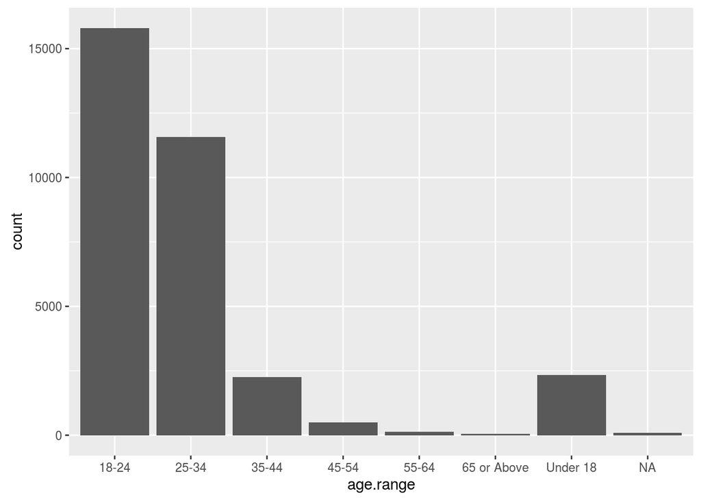

```r
library(ggplot2)
qplot(data = reddit, x = age.range)
```

Now the graph is in order but the ‘Under 18’ group should have been the first one. For this to happen we want ordered factors.

### 18 - Setting Levels of Ordered Factors

The problem is much worse in some other cases.

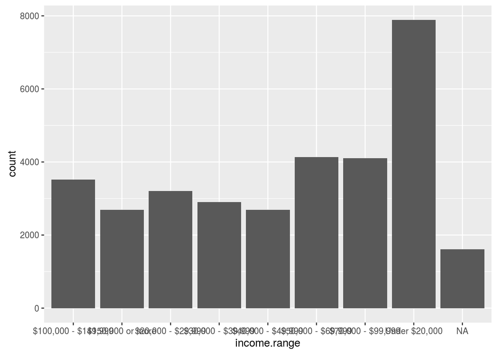

```r
qplot(data = reddit, x = income.range)
```

Setting the order can be done like this

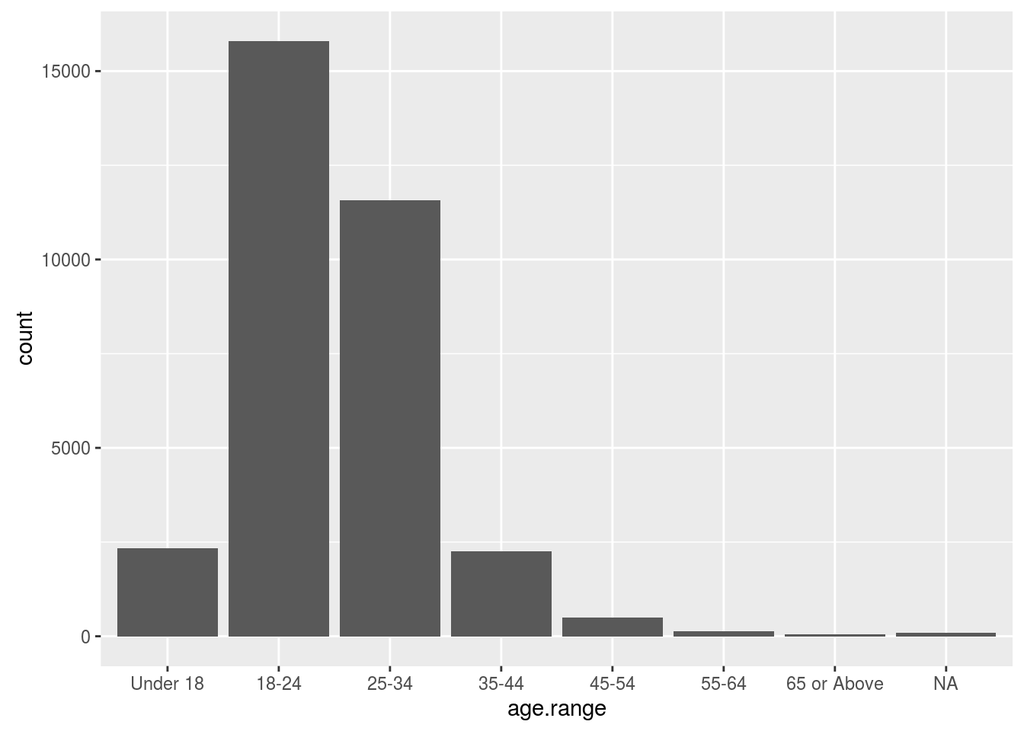

```r
reddit$age.range <- ordered(reddit$age.range,
                            levels = c('Under 18', '18-24', '25-34', '35-44', '45-54',
                                       '55-64', '65 or Above'))

qplot(data = reddit, x = age.range)
```

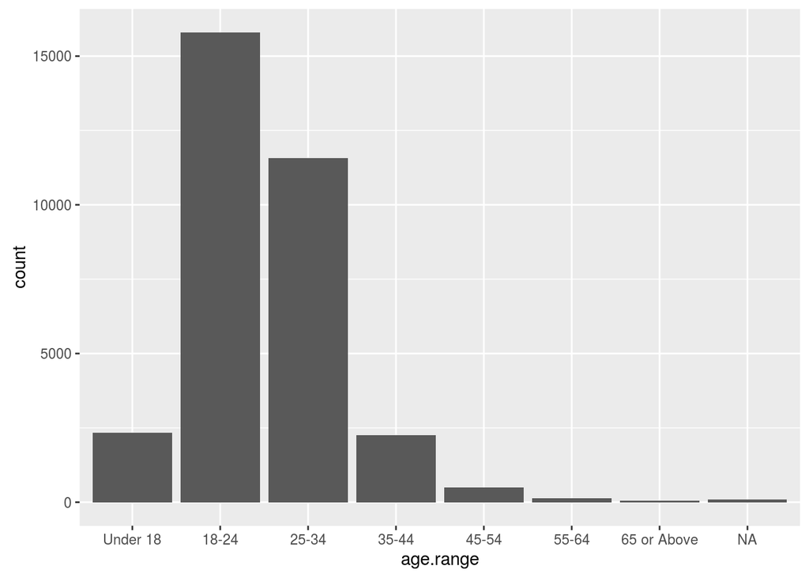

```r
#Alternate way to set order of factors
reddit$age.range <- factor(reddit$age.range,
                            levels = c('Under 18', '18-24', '25-34', '35-44', '45-54',
                                       '55-64', '65 or Above'),
                           ordered = T)

qplot(data = reddit, x = age.range)
```

#### Resources

- [Learn how to set and order factor levels.](http://statistics.ats.ucla.edu/stat/r/modules/factor_variables.htm)

### 19 - Data Munging

- Data sets used so far were tidy
- Normally we won’t have tidy data
- Or we may have to reshape or re arrange data into different formats

#### Resources

- [Data Wrangling with MongoDB: Data Manipulation and Retrieval](https://www.udacity.com/course/ud032)
- Read this [fantastic tutorial](http://flowingdata.com/2015/02/18/loading-data-and-basic-formatting-in-r/) on loading data into R by Nathan Yau.
- [Tidy Data](http://vita.had.co.nz/papers/tidy-data.pdf) by Hadley Wickham
- [Tidy Data Presentation](http://courses.had.co.nz.s3-website-us-east-1.amazonaws.com/12-rice-bdsi/slides/07-tidy-data.pdf) by Hadley Wickham (June 2012)

### 20 - Advice for Data Scientists

- Find data sets that you are interested in
- Work with them, play with the data
- Good data science come from good questions, not fancy techniques
- Motivating the research with an idea that you care about

#### Resources

- [Eytan Bakshy](http://eytan.github.io/)
- [Sean Taylor](http://seanjtaylor.com/)